# Practical Machine Learning Final Assignment

Lisa Doelger

4/25/2019

## Overview of Assignment

For this assignment we were asked to use the Weight Lifting Exercise Dataset to predict the classe variable or the way in which six participants completed a barbell exercise. In this assignment I will be explaining the following (taken straight from the assignment):  
-how I built my model  
-how I used cross validation  
-what I think the expected out of sample error is  
-why I made the choices I did

### Packages

My first step was to install the packages needed to complete the assignment. I wanted to be able to see skew and kurtosis of all the variables in one list, so I included the psych package.

```r
library(ggplot2)
library(lattice)
library(caret)
library(psych)
```

### Upload training data & examine file

My next step was to bring in the training dataset, and take a look at it using summary, structure, and head functions. (I’m not including the code below for viewing the data to save on space.)

I loaded the testing dataset to take a peek at the fields. The same fields with high missingness in the training dataset were completely missing in the testing dataset. I made the decision to remove the fields with high or complete missingness in both datasets, and removed the new_window value of yes rows in the training set (since these rows represent the summary of other rows).

I also made the decision to remove a few other fields. I removed the first column because it was simply a count of the rows. I removed raw_timestamp_part_1 and raw_timestamp_part_2, and instead kept cvtd_timestamp. I removed new_window since it no longer provided any variation. I then set the testing data-set to the side until the end of the project.

```r
training = read.csv("~/Desktop/pml-training.csv")
summary(training$new_window)
```

```
##    no   yes
## 19216   406
```

```r
summary(training$max_roll_belt)
```

```
##    Min. 1st Qu.  Median    Mean 3rd Qu.    Max.    NA's
## -94.300 -88.000  -5.100  -6.667  18.500 180.000   19216
```

```r
testing = read.csv("~/Desktop/pml-testing.csv")

training2 <- training[training$new_window=="no",c(2,5,7:11,37:49,60:68,84:86,102,113:124,140,151:160)]
testing2 <- testing[,c(2,5,7:11,37:49,60:68,84:86,102,113:124,140,151:159)]
```

### Data Exploration

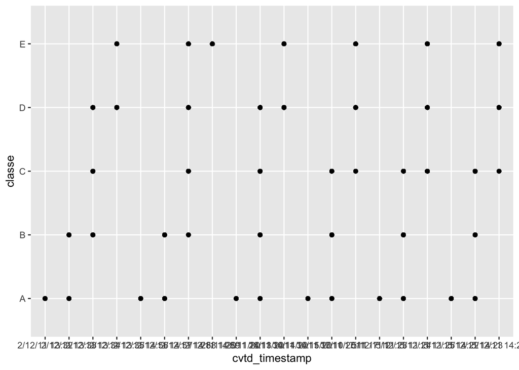

```r
qplot(cvtd_timestamp, classe, data=training2)
```

### K-Fold Cross-Validation

My next step was to set-up my cross validation. I decided to use 5 folds since it falls within the range of number of folds typically used for modeling (three to ten). I used a seed to ensure the same cases were assigned to train and test within each fold across all of my models.

```r
set.seed(333)
data_ctrl <- trainControl(method = "cv", number =5)
```

### Model Runs

The six models I ran are listed below:  
- Multinomial Regression  
- Multinomial Regression with PCA  
- Random Forest  
- Random Forest with PCA  
- Boosting  
- Boosting with PCA

I made sure to set the same seed before each model run to allow for an apple to apple comparison of the models.

```r
set.seed(333)
model_one <- train(classe~., data=training2, trControl=data_ctrl, method="multinom", preProcess=c("center","scale"))


set.seed(333)
model_two <- train(classe~., data=training2, trControl=data_ctrl, method = "multinom", preProcess = c("center", "scale", "pca"))


set.seed(333)
model_three <- train(classe~., data=training2, trControl=data_ctrl, method="rf", preProcess=c("center", "scale"))


set.seed(333)
model_four <- train(classe~., data=training2, trControl=data_ctrl, method="rf", preProcess=c("center", "scale","pca"))


set.seed(333)
model_five <- train(classe~., data=training2, trControl=data_ctrl, method="gbm", preProcess=c("center", "scale"))


set.seed(333)
model_six <- train(classe~., data=training2, trControl=data_ctrl, method="gbm", preProcess=c("center", "scale","pca"))
```

```
## Penalized Multinomial Regression
##
## 19216 samples
##    55 predictor
##     5 classes: 'A', 'B', 'C', 'D', 'E'
##
## Pre-processing: centered (77), scaled (77)
## Resampling: Cross-Validated (5 fold)
## Summary of sample sizes: 15372, 15373, 15373, 15373, 15373
## Resampling results across tuning parameters:
##
##   decay  Accuracy   Kappa
##   0e+00  0.8896757  0.8602721
##   1e-04  0.8898839  0.8605379
##   1e-01  0.8895195  0.8600744
##
## Accuracy was used to select the optimal model using the largest value.
## The final value used for the model was decay = 1e-04.
```

```
## Penalized Multinomial Regression
##
## 19216 samples
##    55 predictor
##     5 classes: 'A', 'B', 'C', 'D', 'E'
##
## Pre-processing: centered (77), scaled (77), principal component
##  signal extraction (77)
## Resampling: Cross-Validated (5 fold)
## Summary of sample sizes: 15372, 15373, 15373, 15373, 15373
## Resampling results across tuning parameters:
##
##   decay  Accuracy   Kappa
##   0e+00  0.7669653  0.7053028
##   1e-04  0.7667573  0.7052140
##   1e-01  0.7677980  0.7064057
##
## Accuracy was used to select the optimal model using the largest value.
## The final value used for the model was decay = 0.1.
```

```
## Random Forest
##
## 19216 samples
##    55 predictor
##     5 classes: 'A', 'B', 'C', 'D', 'E'
##
## Pre-processing: centered (77), scaled (77)
## Resampling: Cross-Validated (5 fold)
## Summary of sample sizes: 15372, 15373, 15373, 15373, 15373
## Resampling results across tuning parameters:
##
##   mtry  Accuracy   Kappa
##    2    0.9863658  0.9827478
##   39    0.9986470  0.9982885
##   77    0.9975541  0.9969060
##
## Accuracy was used to select the optimal model using the largest value.
## The final value used for the model was mtry = 39.
```

```
## Random Forest
##
## 19216 samples
##    55 predictor
##     5 classes: 'A', 'B', 'C', 'D', 'E'
##
## Pre-processing: centered (77), scaled (77), principal component
##  signal extraction (77)
## Resampling: Cross-Validated (5 fold)
## Summary of sample sizes: 15372, 15373, 15373, 15373, 15373
## Resampling results across tuning parameters:
##
##   mtry  Accuracy   Kappa
##    2    0.9857412  0.9819601
##   39    0.9818383  0.9770251
##   77    0.9814219  0.9764984
##
## Accuracy was used to select the optimal model using the largest value.
## The final value used for the model was mtry = 2.
```

```
## Stochastic Gradient Boosting
##
## 19216 samples
##    55 predictor
##     5 classes: 'A', 'B', 'C', 'D', 'E'
##
## Pre-processing: centered (77), scaled (77)
## Resampling: Cross-Validated (5 fold)
## Summary of sample sizes: 15372, 15373, 15373, 15373, 15373
## Resampling results across tuning parameters:
##
##   interaction.depth  n.trees  Accuracy   Kappa
##   1                   50      0.8275922  0.7811049
##   1                  100      0.8852525  0.8547302
##   1                  150      0.9109078  0.8871652
##   2                   50      0.9222006  0.9014717
##   2                  100      0.9598255  0.9491560
##   2                  150      0.9787160  0.9730730
##   3                   50      0.9548295  0.9428261
##   3                  100      0.9857934  0.9820299
##   3                  150      0.9932870  0.9915094
##
## Tuning parameter 'shrinkage' was held constant at a value of 0.1
##
## Tuning parameter 'n.minobsinnode' was held constant at a value of 10
## Accuracy was used to select the optimal model using the largest value.
## The final values used for the model were n.trees = 150,
##  interaction.depth = 3, shrinkage = 0.1 and n.minobsinnode = 10.
```

```
## Stochastic Gradient Boosting
##
## 19216 samples
##    55 predictor
##     5 classes: 'A', 'B', 'C', 'D', 'E'
##
## Pre-processing: centered (77), scaled (77), principal component
##  signal extraction (77)
## Resampling: Cross-Validated (5 fold)
## Summary of sample sizes: 15372, 15373, 15373, 15373, 15373
## Resampling results across tuning parameters:
##
##   interaction.depth  n.trees  Accuracy   Kappa
##   1                   50      0.7234592  0.6484486
##   1                  100      0.7885616  0.7321734
##   1                  150      0.8168714  0.7682585
##   2                   50      0.8160913  0.7671976
##   2                  100      0.8692760  0.8346178
##   2                  150      0.8929020  0.8644968
##   3                   50      0.8564739  0.8184750
##   3                  100      0.8999796  0.8734738
##   3                  150      0.9230855  0.9026741
##
## Tuning parameter 'shrinkage' was held constant at a value of 0.1
##
## Tuning parameter 'n.minobsinnode' was held constant at a value of 10
## Accuracy was used to select the optimal model using the largest value.
## The final values used for the model were n.trees = 150,
##  interaction.depth = 3, shrinkage = 0.1 and n.minobsinnode = 10.
```

After my model runs, I compared their accuracy on the hold-out data from my 5-fold cross-validation in order to estimate out of sample error, and determine the best fit to the data. Interestingly the PCA models all performed worse than the models that used the center and scaled predictors. Out of all the models, the random forest model performed best with an extremely high accuracy of 99.8647% and an out of sample error of 0.1353%.With such a high accuracy and out of sample error using this method, I decided to move forward with the random forest as the final model.

### Predictions on the Test Dataset

My final step was to use the random forest model to predict the classe variable in the test dataset.

```r
pred <- predict(model_three, testing2)
pred
```

```
##  [1] B A B A A E D B A A B C B A E E A B B B
## Levels: A B C D E
```